# Butterfly Project

Andy Barton, Jen Mo, Yue Ren

October 8, 2016

## Introduction

Evan Kristiansen from biology conducted an experiment which aimed to test the hypothesis of Batesian mimicry. This theory states that if one animal is toxic or dangerous to predators in some way and a similar looking animal is not, the animal that is not toxic is attacked less frequently because predators confuse it with the toxic animal.

In order to test this, he set up test group (paper model butterflies) which contains two kinds of butterflies that are supposed to be in a “Batesian mimicry” relationship. That since one butterfly is toxic and conspicuously coloured, the other butterfly gains protection from predation by being similarly coloured despite being palatable. Then he set up two control groups; a novelty control which is not native to the region and therefore unknown to preditors and a palatable control which is a native species that the predators likely eat on a regular basis. This palatable control should represent the base-level attack rate.

## Experimental design

- Each model is set out in the field for a total of 96 hours (4 days). He set them out, then check them every 24 hours for attacks.
- Each site has 20 models in it, 5 of each kind.
- There are 100 sites in California.
- This means that each location (californica and Idaho) had a total of 500 models of each type, or 2000 models total.
- Since each model is checked 4 times, he has 8000 observations in each location (CA, which is where our data comes from, and ID).
- The types of Butterflies used included
  - A. Californica (Batesian Model, toxic)
  - L. Lorguini (Batesian Model, palatable but looks like A. Californica)
  - L. Weidemeyerii (Novelty Control)
  - J. Coenia (Palatable Control)

## Approach

Initial analysis, done by Evan before meeting with us, used a poisson regression to test whether there were significant differences in the number of attacks on each butterly at each site. He found a significant difference in the attack patterns between the J. coenia and A. Californica (the batesian model), but did not find a similar significant difference between J. coenia and L. Lorguini (the batesian mimic), as the hypothesis predicts.

Of the 8000 observations of possible attacks, only 33 attacks were actually found. Evan approached us to better understand how to analyse data when working with so many zero values. We then attempted a number of different approaches:

- Table Analysis: Here we included only sites where attacks occured and performed Fisher’s exact tests to see if there are significant differences between butterfly types.
- Zero Inflated Poisson Regression: This is a form of poisson regression that takes into account a high proportion of 0s, here the amount of zeros is less problematic and he can still use a poisson type regression which is common in his field.
- Logistic Regression: for each of the 8000 observed attack opportunities, this tests how butterfly types affect the probability of attack.

We have listed these approaches from what we consider to be the best approach to modeling the data, to the most problematic.

## Table Analysis: Fisher’s Exact Test

We performed Fisher’s Exact Tests at site level, sites where attacks occured vs sites they did not occur, and at attack level, attacks vs unattacked butterflies. In setting up the tables for analysis, we did not include data from sites where no attacks occured. For example, for Buttfly A, of the 25 sites where any attacks occured, there were 4 sites that were attacked and 21 sites that were not attacked.

### Based on Site Level

We chose to conduct Fisher’s Exact Test because it determines if there are nonrandom associations between two categorical variables. It generates the total probability of the least likely events until the probability adds up to 0.05. For the first test, we separated the data of each type of butterfly by attacked and not attacked sites. For example, for butterfly A, there were 4 sites that were attacked and 21 sites that were not attacked. We compared two types of butterflies for each test and were able to reach the conclusion those only butterflies A and J has statistically significant association since this was the only test with a p-vaue of less than 0.05.

Attack by site

```r
A_L=rbind(c(4,21),c(6,19))
A_L
```

```
##      [,1] [,2]
## [1,]    4   21
## [2,]    6   19
```

```r
fisher.test(A_L)
```

```
##
##  Fisher's Exact Test for Count Data
##
## data:  A_L
## p-value = 0.7252
## alternative hypothesis: true odds ratio is not equal to 1
## 95 percent confidence interval:
##  0.1088418 3.0321155
## sample estimates:
## odds ratio
##  0.6093046
```

```r
J_W=rbind(c(12,13),c(9,16))
J_W
```

```
##      [,1] [,2]
## [1,]   12   13
## [2,]    9   16
```

```r
fisher.test(J_W)
```

```
##
##  Fisher's Exact Test for Count Data
##
## data:  J_W
## p-value = 0.5672
## alternative hypothesis: true odds ratio is not equal to 1
## 95 percent confidence interval:
##  0.4596131 5.9319591
## sample estimates:
## odds ratio
##   1.624654
```

```r
A_J=rbind(c(4,21),c(12,13))
A_J
```

```
##      [,1] [,2]
## [1,]    4   21
## [2,]   12   13
```

```r
fisher.test(A_J)
```

```
##
##  Fisher's Exact Test for Count Data
##
## data:  A_J
## p-value = 0.03216
## alternative hypothesis: true odds ratio is not equal to 1
## 95 percent confidence interval:
##  0.04105302 0.89670128
## sample estimates:
## odds ratio
##  0.2133287
```

signifcant

```r
L_W=rbind(c(6,19),c(9,16))
L_W
```

```
##      [,1] [,2]
## [1,]    6   19
## [2,]    9   16
```

```r
fisher.test(L_W)
```

```
##
##  Fisher's Exact Test for Count Data
##
## data:  L_W
## p-value = 0.538
## alternative hypothesis: true odds ratio is not equal to 1
## 95 percent confidence interval:
##  0.1343541 2.2463926
## sample estimates:
## odds ratio
##  0.5679574
```

At the 5% level, we only find a significant difference between J. coenia and A. Californica, the same significance pattern as Evan found in the poisson regression model.

### Based on Attack Level

Another way we looked at the data was to seperate each butterfly types by attacked or not attacked. For example, between A and J, there were 4 and 13 butterflies attacked respectively. In terms of sites, 4 sites of A were atacked and 12 sites of J were attacked. If the total of sites attacked between the two types of butterflies were attacked equals to 16 sites then that means there were 320 total possibles attacks (16*20). Therefore, we then would compare the number of butterflies that were attacked and not attacked by type. Butterfly A would have 4 butterflies attacked nad 316 butterflies not attacked and BUttefly J would have 13 butterflies attacked and 307 butterflies not attacked.

```r
A_L=rbind(c(4,196),c(6,194))
A_L
```

```
##      [,1] [,2]
## [1,]    4  196
## [2,]    6  194
```

```r
fisher.test(A_L)
```

```
##
##  Fisher's Exact Test for Count Data
##
## data:  A_L
## p-value = 0.7508
## alternative hypothesis: true odds ratio is not equal to 1
## 95 percent confidence interval:
##  0.1349133 2.8348089
## sample estimates:
## odds ratio
##  0.6605457
```

```r
A_J <- rbind(c(4,316),c(13,307))
A_J
```

```
##      [,1] [,2]
## [1,]    4  316
## [2,]   13  307
```

```r
fisher.test(A_J)
```

```
##
##  Fisher's Exact Test for Count Data
##
## data:  A_J
## p-value = 0.04611
## alternative hypothesis: true odds ratio is not equal to 1
## 95 percent confidence interval:
##  0.07036603 0.98314614
## sample estimates:
## odds ratio
##   0.299428
```

```r
J_W=rbind(c(12,408),c(10,410))
J_W
```

```
##      [,1] [,2]
## [1,]   12  408
## [2,]   10  410
```

```r
fisher.test(J_W)
```

```
##
##  Fisher's Exact Test for Count Data
##
## data:  J_W
## p-value = 0.8296
## alternative hypothesis: true odds ratio is not equal to 1
## 95 percent confidence interval:
##  0.4714234 3.1529727
## sample estimates:
## odds ratio
##   1.205612
```

```r
L_W <- rbind(c(6,294),c(10,290))
L_W
```

```
##      [,1] [,2]
## [1,]    6  294
## [2,]   10  290
```

```r
fisher.test(L_W)
```

```
##
##  Fisher's Exact Test for Count Data
##
## data:  L_W
## p-value = 0.4483
## alternative hypothesis: true odds ratio is not equal to 1
## 95 percent confidence interval:
##  0.1745766 1.8262744
## sample estimates:
## odds ratio
##  0.5923488
```

By grouping based on butterfly types, we calculated the number of the butterflies of the same species that were attacked vs the number of the same type of butterflies in sites that were not attacked. We found that the difference in attack patterns between J. coenia and A. Californica has statistical significance based on having a p-value that is less than 0.05.

## Why not Poisson Regression

The initial analysis was done using a poisson regression, a very common model to use in the field. This assumes that the outcome variable follows a poisson distribution.

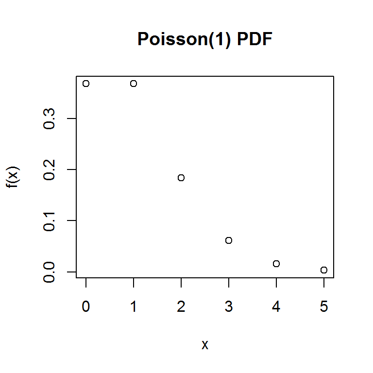

```r
x <- seq(0, 5, 1)
plot(x, dpois(x, 1), type = "p", ylab = "f(x)", main = "Poisson(1) PDF")
```

Here is a plot of the poisson distribution of mean 1 to illustrate the way a poisson distributed variable approximately behaves.

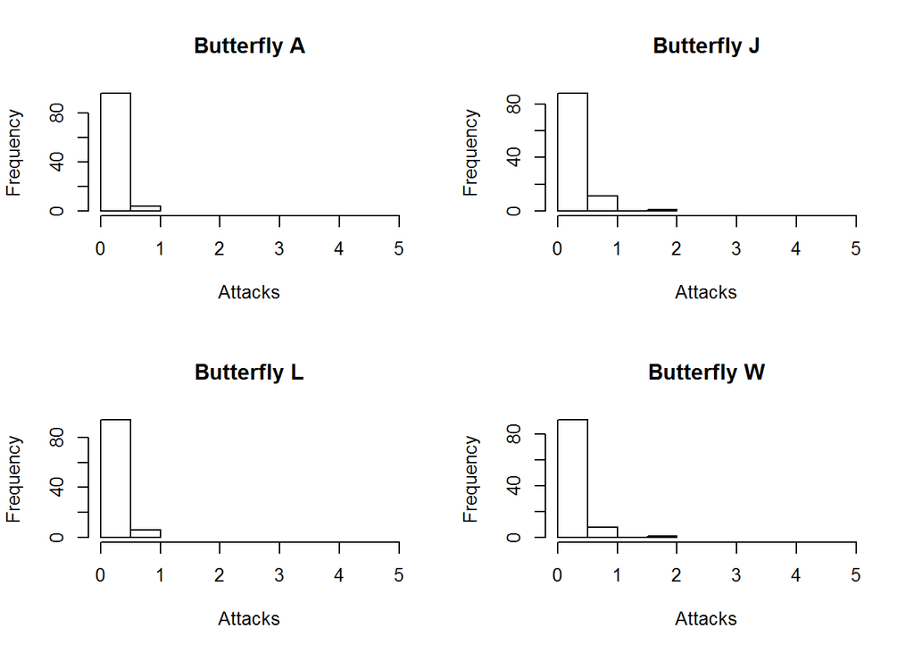

```r
par(mfrow = c(2, 2))
hist(butterfly_data[butterfly_data$Treatment == "A", "Attacked"], breaks = 2, xlim = c(0,5),
     xlab = "Attacks", main = "Butterfly A")
hist(butterfly_data[butterfly_data$Treatment == "J", "Attacked"], breaks = 3, xlim = c(0,5),
     xlab = "Attacks", main = "Butterfly J")
hist(butterfly_data[butterfly_data$Treatment == "L", "Attacked"], breaks = 2, xlim = c(0,5),
     xlab = "Attacks", main = "Butterfly L")
hist(butterfly_data[butterfly_data$Treatment == "W", "Attacked"], breaks = 3, xlim = c(0,5),
     xlab = "Attacks", main = "Butterfly W")
```

As you can see from these histograms, the distribution of the attack variable is too heavily skewed toward 0 to reasonably assume if follows a poisson distribution. For this reason, we need to adjust our model.

## Zero Inflated Poisson Regression

Zero-inflated Poisson regression is a model for count data with excess zeros. It assumes that with a probability p the only posssible observation is 0, and with probability 1 - p, a Poisson($\lambda$) random variable is observed (Lambert, Technometrics 1992).

In this case, a zero-inflated poisson regression model does not apply here because the current data set doesn’t contain enought observations away from 0. In addition, the difference between the number of observations that are zero and non-zero is too dramatic to effectively use this model. Therefore we attempted to use Logistic regression and Fisher’s exact test to examine for statistical significance.

## Logistic Regression

Logistic regressions is used to analyse how independent variables affect the probability of a binary outcome variable being 1. In this case, we look at each observation of whether or not a butterfly was attacked on a certain day at a certain site, giving us 8000 observations. If a coefficient on a butterfly type is positive (negative) and significant, then that type is significantly more (less) likely to be attacked than the ommitted group. By running the regression 3 times, we can get coefficients and p values for comparisons between all four groups.

```r
#setwd("/Users/lijun/Dropbox/2016Fall/TA_Consulting/2_Evan_butterfly_project/Butterfly #Writeup/Jun_view")
mydata <- read.csv("California_2016_Model_data.csv", header = TRUE)

mydata$model_A <- as.numeric(c(mydata$Model == "A. californica"))
mydata$model_L <- as.numeric(c(mydata$Model == "L. lorquini"))



mydata$model_W <- as.numeric(c(mydata$Model == "L. weidemeyerii"))
mydata$model_J <- as.numeric(c(mydata$Model == "J. coenia"))

mydata$model_JW <- ifelse(mydata$model_W == 1 | mydata$model_J == 1, 1, 0)


logit_1_output <- glm(Attack ~ model_A + model_L + model_W, data = mydata, family = "binomial")
df_14 <- summary(logit_1_output)$coefficients[2,c(1,2,4)]
df_24 <- summary(logit_1_output)$coefficients[3,c(1,2,4)]
df_34 <- summary(logit_1_output)$coefficients[4,c(1,2,4)]

logit_2_output <- glm(Attack ~ model_A + model_L + model_J, data = mydata, family = "binomial")
df_13 <- summary(logit_2_output)$coefficients[2,c(1,2,4)]
df_23 <- summary(logit_2_output)$coefficients[3,c(1,2,4)]

logit_3_output <- glm(Attack ~ model_A + model_W + model_J, data = mydata, family = "binomial")
df_12 <- summary(logit_3_output)$coefficients[2,c(1,2,4)]

output_df <- data.frame("Testing" = c("A over L", "A over W", "A over J",
                                      "L over W", "L over J","W over J"),
                        "Coefficient" = c(df_12[[1]], df_13[[1]], df_14[[1]],
                                          df_23[[1]], df_24[[1]], df_34[[1]]),
                        "Standard Error" = c(df_12[[2]], df_13[[2]], df_14[[2]],
                                          df_23[[2]], df_24[[2]], df_34[[2]]),
                        "P-Value" = c(df_12[[3]], df_13[[3]], df_14[[3]],
                                          df_23[[3]], df_24[[3]], df_34[[3]]))


logit_4_output <- glm(Attack~model_L+model_JW, data = mydata, family = "binomial")
#This compares J&W to A
summary(logit_4_output)
```

```
##
## Call:
## glm(formula = Attack ~ model_L + model_JW, family = "binomial",
##     data = mydata)
##
## Deviance Residuals:
##     Min       1Q   Median       3Q      Max
## -0.1097  -0.1097  -0.0775  -0.0633   3.5255
##
## Coefficients:
##             Estimate Std. Error z value Pr(>|z|)
## (Intercept)  -6.2126     0.5005 -12.413   <2e-16 ***
## model_L       0.4065     0.6463   0.629   0.5294
## model_JW      1.1026     0.5408   2.039   0.0414 *
## ---
## Signif. codes:  0 '***' 0.001 '**' 0.01 '*' 0.05 '.' 0.1 ' ' 1
##
## (Dispersion parameter for binomial family taken to be 1)
##
##     Null deviance: 439.19  on 7999  degrees of freedom
## Residual deviance: 432.82  on 7997  degrees of freedom
## AIC: 438.82
##
## Number of Fisher Scoring iterations: 9
```

```r
logit_5_output <- glm(Attack~model_A+model_JW, data = mydata, family = "binomial")
#This compares J&W to L
summary(logit_5_output)
```

```
##
## Call:
## glm(formula = Attack ~ model_A + model_JW, family = "binomial",
##     data = mydata)
##
## Deviance Residuals:
##     Min       1Q   Median       3Q      Max
## -0.1097  -0.1097  -0.0775  -0.0633   3.5255
##
## Coefficients:
##             Estimate Std. Error z value Pr(>|z|)
## (Intercept)  -5.8061     0.4089 -14.201   <2e-16 ***
## model_A      -0.4065     0.6463  -0.629    0.529
## model_JW      0.6962     0.4573   1.522    0.128
## ---
## Signif. codes:  0 '***' 0.001 '**' 0.01 '*' 0.05 '.' 0.1 ' ' 1
##
## (Dispersion parameter for binomial family taken to be 1)
##
##     Null deviance: 439.19  on 7999  degrees of freedom
## Residual deviance: 432.82  on 7997  degrees of freedom
## AIC: 438.82
##
## Number of Fisher Scoring iterations: 9
```

```r
kable(output_df, digits = 3)
```

| Testing | Coefficient | Standard.Error | P.Value |
| --- | --- | --- | --- |
| A over L | -0.406 | 0.646 | 0.529 |
| A over W | -1.015 | 0.585 | 0.083 |
| A over J | -1.183 | 0.573 | 0.039 |
| L over W | -0.609 | 0.509 | 0.231 |
| L over J | -0.777 | 0.495 | 0.116 |
| W over J | -0.168 | 0.411 | 0.683 |

```r
glm_fit <- glm(Attack ~ Model, data = mydata, family = "binomial")
summary(glht(glm_fit, mcp(Model="Tukey")))
```

```
##
##   Simultaneous Tests for General Linear Hypotheses
##
## Multiple Comparisons of Means: Tukey Contrasts
##
##
## Fit: glm(formula = Attack ~ Model, family = "binomial", data = mydata)
##
## Linear Hypotheses:
##                                       Estimate Std. Error z value Pr(>|z|)
## J. coenia - A. californica == 0         1.1832     0.5726   2.066    0.160
## L. lorquini - A. californica == 0       0.4065     0.6463   0.629    0.921
## L. weidemeyerii - A. californica == 0   1.0151     0.5847   1.736    0.299
## L. lorquini - J. coenia == 0           -0.7767     0.4946  -1.570    0.389
## L. weidemeyerii - J. coenia == 0       -0.1681     0.4109  -0.409    0.976
## L. weidemeyerii - L. lorquini == 0      0.6086     0.5085   1.197    0.623
## (Adjusted p values reported -- single-step method)
```

```r
mydata$comb.model <- ifelse(mydata$model_A == 1, "A", "")
mydata$comb.model <- ifelse(mydata$model_L == 1, "L", mydata$comb.model)
mydata$comb.model <- ifelse(mydata$model_JW == 1, "JW", mydata$comb.model)
#table(mydata$comb.model)
mydata$comb.model <- as.factor(mydata$comb.model)

glm_fit <- glm(Attack ~ comb.model, data = mydata, family = "binomial")
summary(glht(glm_fit, mcp(comb.model="Tukey")))
```

```
##
##   Simultaneous Tests for General Linear Hypotheses
##
## Multiple Comparisons of Means: Tukey Contrasts
##
##
## Fit: glm(formula = Attack ~ comb.model, family = "binomial", data = mydata)
##
## Linear Hypotheses:
##             Estimate Std. Error z value Pr(>|z|)
## JW - A == 0   1.1026     0.5408   2.039   0.0998 .
## L - A == 0    0.4065     0.6463   0.629   0.8000
## L - JW == 0  -0.6962     0.4573  -1.522   0.2739
## ---
## Signif. codes:  0 '***' 0.001 '**' 0.01 '*' 0.05 '.' 0.1 ' ' 1
## (Adjusted p values reported -- single-step method)
```

There are some troubling assumptions associated with using this model. For example, this treats every observation as completely independent, but comparing a given model day 1 vs day 2 is different from a model day 1 at site x to a model day 1 at site y. Treating these data as counts of attacks is a better way to model than treating it as attack opportunities that either did or did not have an attack.